# Projekt 1 - Faza 3

Adrian Gąsiorowski, Agnieszka Linowska, Bartosz Piotrowski, Krzysztof Rutkowski

12.04.2016r.

W poniższej prezentacji pokażemy, jak znaleźliśmy strukturę w zbiorze odwiedzających pod kątem czasu przebywania przy eksponatach, przy użyciu własnej metryki.

# Przygotowanie danych

```r
library(ggplot2)
library(cluster)
library(factoextra)
library(MASS)
library(ggrepel)
```

Korzystamy z oczyszczonych danych z poprzedniej fazy projektu.

```r
load("station_times_reshaped.rda")
load("station_bool_reshaped.rda")
load("station_times_normal.rda")

head(station_times_normal, 20)
```

```
##    visitor station d_of_w month time_spent start_time
## 1   801439  cnk02a Friday     1         20   12.48333
## 2   801447  cnk02a Friday     1         32   10.81667
## 3   801448  cnk02a Friday     1         47   10.80000
## 4   801458  cnk02a Friday     1        478   10.36667
## 5   801482  cnk02a Friday     1         58   11.28333
## 6   801483  cnk02a Friday     1        685   11.30000
## 7   801487  cnk02a Friday     1         40   13.85000
## 8   801488  cnk02a Friday     1        254   14.08333
## 9   801491  cnk02a Friday     1         30   10.55000
## 10  801492  cnk02a Friday     1          5   10.55000
## 11  801493  cnk02a Friday     1         33   10.56667
## 12  801498  cnk02a Friday     1         30   10.56667
## 13  801510  cnk02a Friday     1         10   13.61667
## 14  801513  cnk02a Friday     1         70   10.66667
## 15  801516  cnk02a Friday     1         27   13.61667
## 16  801519  cnk02a Friday     1         58   10.71667
## 17  801521  cnk02a Friday     1         20   10.70000
## 18  801523  cnk02a Friday     1         59   11.70000
## 19  801524  cnk02a Friday     1         15   12.88333
## 20  801526  cnk02a Friday     1         29   11.65000
```

```r
station_times_reshaped[1:20, 1:10]
```

```
##         cnk02a cnk02b cnk03 cnk05 cnk06 cnk07 cnk09 cnk100 cnk10 cnk11
## 1000001      0      0     0     0     0     0     0      0     0     0
## 1000002      0     30     0     0     0     0     0      0     0     0
## 1000003      0      0     0     0    83     0     0      0     0     0
## 1000005      0      0     0     0     0     0     0      0     0     0
## 1000006      9      0    68     0     0    81     0      0     0     0
## 1000008      0      0     0     0     0     0     0      0     0     0
## 1000009      0      0     0     0     0     0     0      0     0     0
## 1000010      0      0     0     0     0     0     0      0     0     0
## 1000011      2      0     0     0     0     0     5      0     0    24
## 1000012      0      0     0     0     0     0     0      0     0     0
## 1000017      0      0     0     0     0     0     0      0     0     0
## 1000018     38      0     0     0     0     0     0      0     0     0
## 1000019     10      0     0     0     0   118    61      0     0     0
## 1000020      0      0     0     0     0    59    38      0     0    73
## 1000022      0      0     0     0     0     0     0      0     0     0
## 1000023      0      0     0     0     0     0     0      0     0     0
## 1000027     68      0     0     0     0     0     0      0     0     0
## 1000028      0     64     0     0     0     0     0      0     0     0
## 1000029      0     25     0     0     0     0     0   1059     0     0
## 1000032      0      0     0     0     0     0     0      0     0     0
```

```r
station_bool_reshaped[1:20,1:10]
```

```
##         cnk02a cnk02b cnk03 cnk05 cnk06 cnk07 cnk09 cnk100 cnk10 cnk11
## 1000001  FALSE  FALSE FALSE FALSE FALSE FALSE FALSE  FALSE FALSE FALSE
## 1000002  FALSE   TRUE FALSE FALSE FALSE FALSE FALSE  FALSE FALSE FALSE
## 1000003  FALSE  FALSE FALSE FALSE  TRUE FALSE FALSE  FALSE FALSE FALSE
## 1000005  FALSE  FALSE FALSE FALSE FALSE FALSE FALSE  FALSE FALSE FALSE
## 1000006   TRUE  FALSE  TRUE FALSE FALSE  TRUE FALSE  FALSE FALSE FALSE
## 1000008  FALSE  FALSE FALSE FALSE FALSE FALSE FALSE  FALSE FALSE FALSE
## 1000009  FALSE  FALSE FALSE FALSE FALSE FALSE FALSE  FALSE FALSE FALSE
## 1000010  FALSE  FALSE FALSE FALSE FALSE FALSE FALSE  FALSE FALSE FALSE
## 1000011   TRUE  FALSE FALSE FALSE FALSE FALSE  TRUE  FALSE FALSE  TRUE
## 1000012  FALSE  FALSE FALSE FALSE FALSE FALSE FALSE  FALSE FALSE FALSE
## 1000017  FALSE  FALSE FALSE FALSE FALSE FALSE FALSE  FALSE FALSE FALSE
## 1000018   TRUE  FALSE FALSE FALSE FALSE FALSE FALSE  FALSE FALSE FALSE
## 1000019   TRUE  FALSE FALSE FALSE FALSE  TRUE  TRUE  FALSE FALSE FALSE
## 1000020  FALSE  FALSE FALSE FALSE FALSE  TRUE  TRUE  FALSE FALSE  TRUE
## 1000022  FALSE  FALSE FALSE FALSE FALSE FALSE FALSE  FALSE FALSE FALSE
## 1000023  FALSE  FALSE FALSE FALSE FALSE FALSE FALSE  FALSE FALSE FALSE
## 1000027   TRUE  FALSE FALSE FALSE FALSE FALSE FALSE  FALSE FALSE FALSE
## 1000028  FALSE   TRUE FALSE FALSE FALSE FALSE FALSE  FALSE FALSE FALSE
## 1000029  FALSE   TRUE FALSE FALSE FALSE FALSE FALSE   TRUE FALSE FALSE
## 1000032  FALSE  FALSE FALSE FALSE FALSE FALSE FALSE  FALSE FALSE FALSE
```

# Selekcja eksponatów

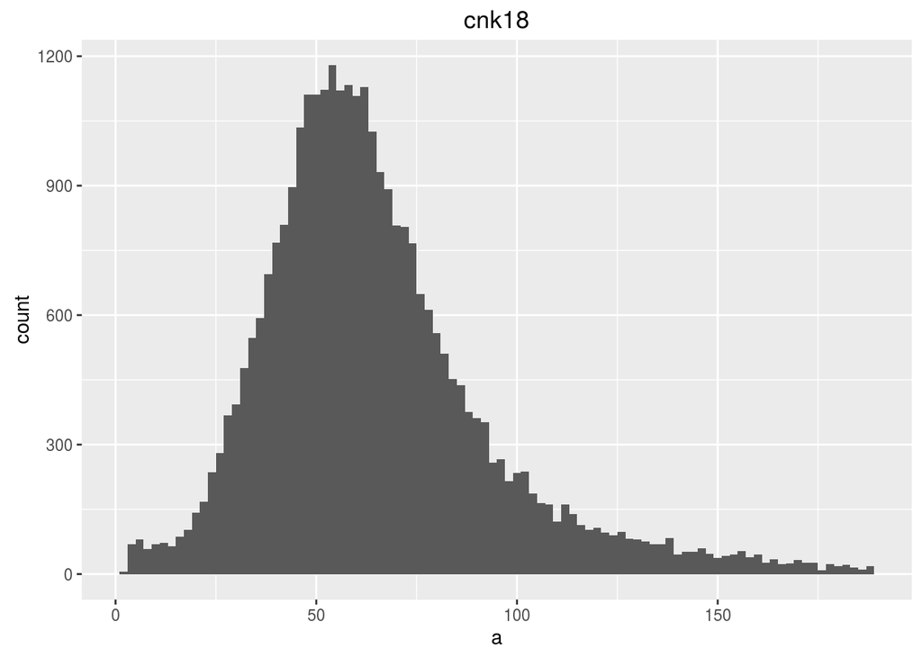

```r
show_hist("cnk18")
```

Ale jest wiele eksponatów, których histogramy wyglądają obiecująco i ciekawie. Np. na histogramie eksponatu *cnk23*, czyli *Flirt czy fiasko*, wyraźnie widać trzy grupy:

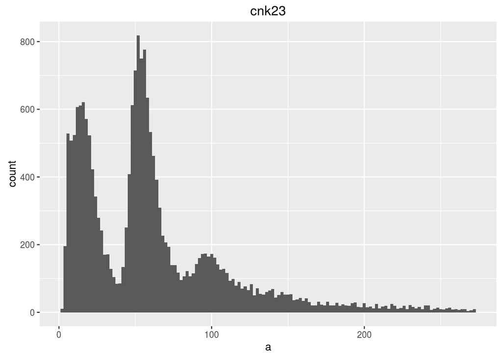

```r
show_hist("cnk23")
```

Z kolei dla eksponatu *cnk07* (*Sprzeczne informacje*), możemy wyróżnić dwie grupy (rozkład bimodalny):

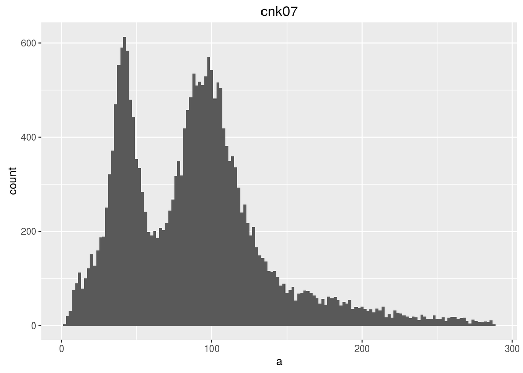

```r
show_hist("cnk07")
```

Eksponatów tego typu, jak dwa powyższe, jest 21. Dla każdego z tych eksponatów podzieliliśmy użytkowników na trzy/cztery grupy i zapisaliśmy to w tabeli:

```r
station_manual_clustering_good[1:20, 1:10]
```

```
##         cnk07 cnk12 cnk13 cnk17 cnk21 cnk24    cnk26 cnk29a cnk38 cnk39
## 1000068     2     2   1.5   0.0     2     0 1.333333      0     2   0.0
## 1000147     0     2   1.5   0.0     2     0 1.333333      0     0   1.0
## 1000148     2     2   1.5   1.5     0     0 0.000000      0     0   0.0
## 1000182     2     2   1.5   1.5     1     0 0.000000      2     2   0.0
## 1000251     0     2   0.0   0.0     0     0 1.333333      0     0   1.0
## 1000294     0     2   1.5   1.5     0     0 0.000000      0     0   0.0
## 1000305     2     2   0.0   1.5     0     0 0.000000      0     0   0.0
## 1000326     0     2   2.0   0.0     0     0 0.000000      0     0   1.0
## 1000349     2     2   1.5   1.5     2     0 0.000000      2     0   1.0
## 1000350     2     2   0.0   1.5     2     2 0.000000      0     0   0.0
## 1000362     0     2   1.5   1.5     0     0 0.000000      0     0   1.0
## 1000417     2     2   1.5   2.0     2     0 0.000000      0     0   0.0
## 1000440     2     2   1.5   1.5     2     2 1.333333      0     0   0.0
## 1000447     2     2   1.5   0.0     0     0 0.000000      0     0   1.0
## 1000468     2     2   1.5   1.5     0     0 0.000000      0     0   1.5
## 1000531     0     2   1.5   1.5     0     0 0.000000      0     0   0.0
## 1000538     2     2   0.0   1.5     2     0 0.000000      0     0   0.0
## 1000563     1     2   0.0   0.0     2     0 0.000000      0     0   0.0
## 1000566     0     2   0.0   0.0     2     2 0.000000      0     0   0.0
## 1000576     0     2   0.0   1.5     2     0 0.000000      0     0   0.0
```

# Nasza metryka

Do obliczania odległości pomiędzy odwiedzającymi stworzyliśmy naszą własną metrykę:

```r
distance <- function(x, y) {
  vis_intersection <- x*y != 0
  manhattan <- abs(x-y)
  nz <- vis_intersection * manhattan
  nz_sum <- sum(vis_intersection)
  return(sum(nz) / (nz_sum*nz_sum))
}
```

Liczy ona odległość manhattan pomiędzy wektorami, ale mnoży jeszcze przez indykator części wspólnej stacji, na których byli obaj odwiedzający. W efekcie wkład do odległości mają jedynie te stacje, na których byli obaj odwiedzający, gdyż tylko tam możemy zdefiniować między nimi jakieś zależności (nie wiemy do końca jak zachowaliby się zwiedzający gdyby byli na innych stacjach). Wyliczoną odległość dzielimy przez kwadrat sumy liczności stacji, na których byli obaj zwiedzający. Premiuje to bardziej te pary odwiedzających (tj są oni sobie bliżsi), którzy przy takich samych średnich różnicach byli razem na większej liczbie stacji.

I przy pomocy tejże metryki stworzyliśmy macierz odległości:

```r
distances_station_manual_clustering_good_reduced[1:10, 1:10]
```

```
##            896887     903201    880616     797872     864204    1073566
## 896887  0.0001000 0.00010000 0.1111111 0.04000000 0.00010000 0.11111111
## 903201  0.0001000 0.00010000 0.2500000 0.12500000 0.05555556 0.16666667
## 880616  0.1111111 0.25000000 0.0001000 0.12500000 0.22222222 0.08000000
## 797872  0.0400000 0.12500000 0.1250000 0.00010000 0.08000000 0.00010000
## 864204  0.0001000 0.05555556 0.2222222 0.08000000 0.00010000 0.05555556
## 1073566 0.1111111 0.16666667 0.0800000 0.00010000 0.05555556 0.00010000
## 973069  0.0400000 0.12500000 0.2222222 0.00010000 0.09375000 0.00010000
## 955187  0.0001000 0.00010000 0.1250000 0.12500000 0.00010000 0.12500000
## 815208  0.0400000 0.10000000 0.1875000 0.02040816 0.02777778 0.02777778
## 876224  0.0001000 0.03125000 0.0625000 0.02777778 0.02777778 0.02777778
##            973069    955187     815208     876224
## 896887  0.0400000 0.0001000 0.04000000 0.00010000
## 903201  0.1250000 0.0001000 0.10000000 0.03125000
## 880616  0.2222222 0.1250000 0.18750000 0.06250000
## 797872  0.0001000 0.1250000 0.02040816 0.02777778
## 864204  0.0937500 0.0001000 0.02777778 0.02777778
## 1073566 0.0001000 0.1250000 0.02777778 0.02777778
## 973069  0.0001000 0.1111111 0.00010000 0.08000000
## 955187  0.1111111 0.0001000 0.04000000 0.06250000
## 815208  0.0001000 0.0400000 0.00010000 0.04687500
## 876224  0.0800000 0.0625000 0.04687500 0.00010000
```

# Rzutowanie 2D

```r
distances_station_manual_clustering_good[distances_station_manual_clustering_good==0] <- 0.0001
distances_station_manual_clustering_good_2d <- isoMDS(distances_station_manual_clustering_good)
```

Wykres Sheparda dla tego rzutowania:

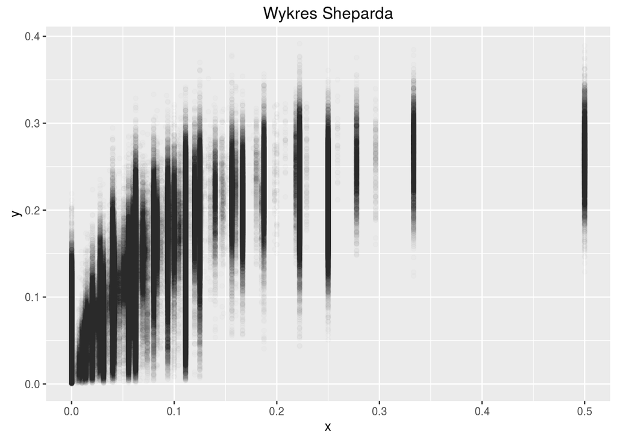

```r
ggplot(shp_r, aes(x=x, y=y)) + geom_point(size = 1.5, alpha = .01) + ggtitle("Wykres Sheparda")
```

Rzutowanie prezentuje się bardzo ładnie:

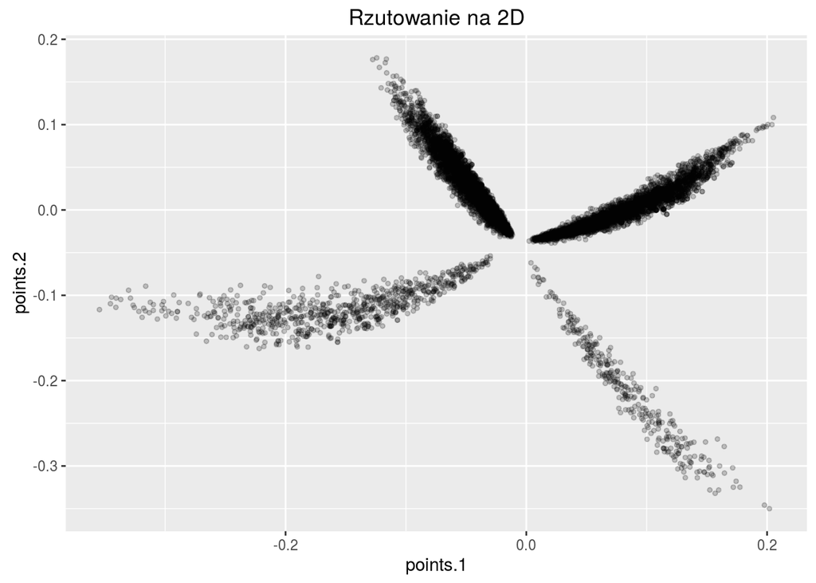

```r
ggplot(as.data.frame(distances_station_manual_clustering_good_2d), aes(x=points.1, y=points.2)) + geom_point(size = 1, alpha=.2) + ggtitle("Rzutowanie na 2D")
```

# Klastrowanie

Do klastrowania zastosowaliśmy metodę *PAM*. Z wykresu w 2D możemy oczekiwać 4 wyraźnych klastrów, ale zbadajmy to jeszcze precyzyjniej metodą Silhouette:

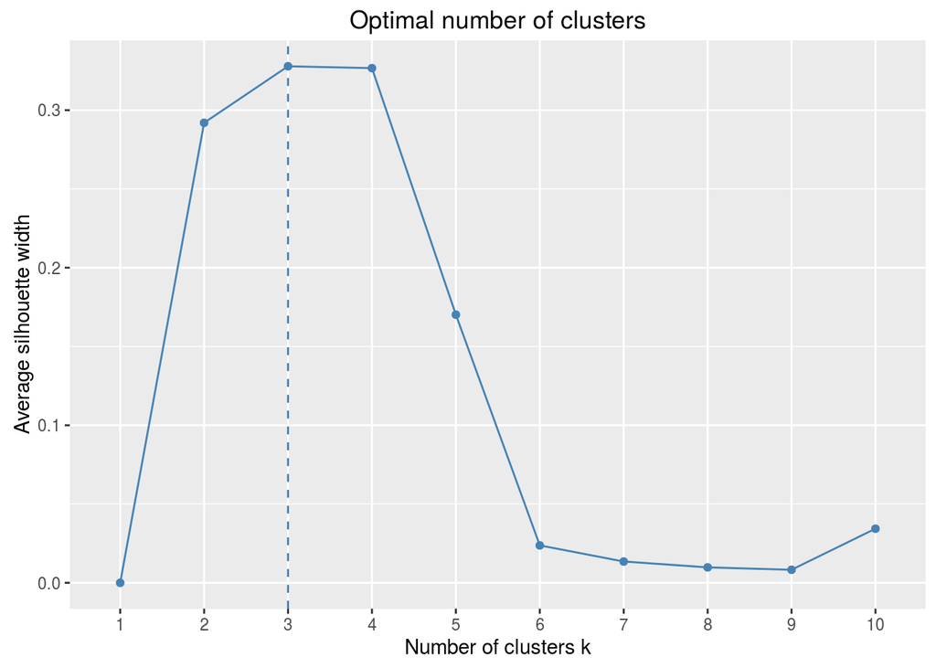

```r
fviz_nbclust(as.dist(distances_station_manual_clustering_good_reduced), pam, method = "silhouette")
```

Wykonujemy klastrowanie PAM dla 4 klastrów:

```r
clst_pam <- pam(as.dist(distances_station_manual_clustering_good), 4)
```

Znajdujemy medoidy:

```r
med <- clst_pam$medoids
med
```

```
## [1] "1042141" "840035"  "848709"  "1055133"
```

Rysujemy wykres z zaznaczonymi medoidami:

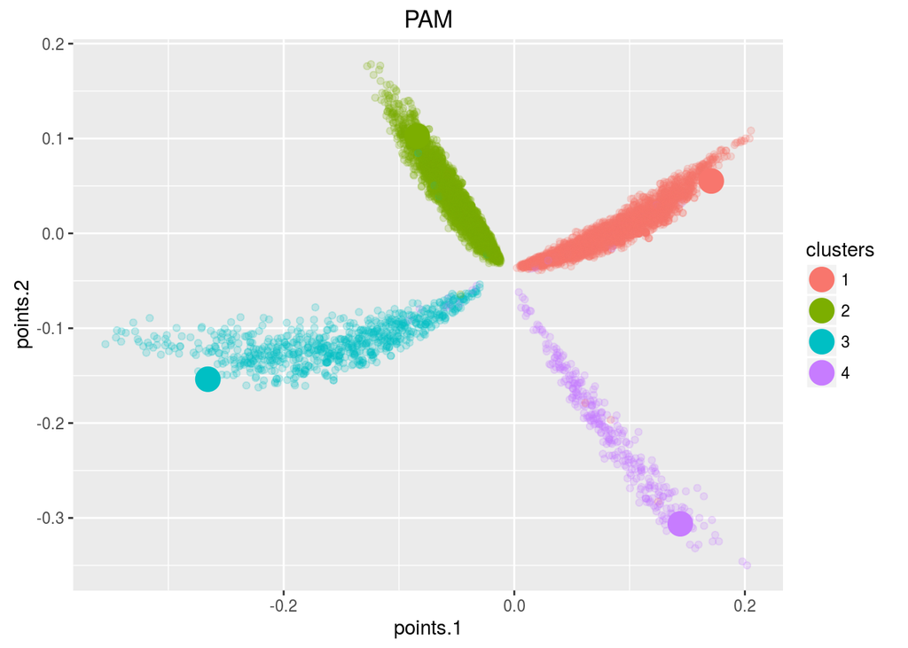

```r
distances_station_manual_clustering_good_2d$clusters <- factor(clst_pam$clustering)
centra <- distances_station_manual_clustering_good_2d[rownames(distances_station_manual_clustering_good_2d) %in% med,]

ggplot(distances_station_manual_clustering_good_2d, aes(x=points.1, y=points.2, colour=clusters)) + geom_point(size = 1.5, alpha=.2) +
  geom_point(data=centra, size=6) + ggtitle("PAM")
```

Kim są odwiedzający będący medoidami?

```r
station_times_normal[station_times_normal$visitor == med[1],]
```

```
##        visitor station d_of_w month time_spent start_time
## 772641 1042141  cnk02b Sunday     4         59   14.26667
## 774075 1042141   cnk05 Sunday     4         94   14.51667
## 775460 1042141   cnk07 Sunday     4         51   14.56667
## 777698 1042141   cnk10 Sunday     4        120   14.43333
## 779556 1042141   cnk12 Sunday     4         48   14.65000
## 781334 1042141   cnk16 Sunday     4         61   14.36667
## 783367 1042141   cnk18 Sunday     4         85   14.85000
## 785156 1042141  cnk19a Sunday     4         19   14.33333
## 786974 1042141  cnk19b Sunday     4         19   14.35000
## 791610 1042141   cnk26 Sunday     4         68   14.95000
## 791998 1042141  cnk29a Sunday     4        286   15.46667
## 799984 1042141   cnk49 Sunday     4         77   15.23333
## 803771 1042141   cnk61 Sunday     4         98   15.11667
```

```r
station_times_normal[station_times_normal$visitor == med[2],]
```

```
##       visitor station d_of_w month time_spent start_time
## 722    840035  cnk02a Friday     1         32   10.26667
## 4139   840035   cnk07 Friday     1         83   10.51667
## 7002   840035   cnk11 Friday     1         67   10.56667
## 7922   840035   cnk12 Friday     1         69   10.48333
## 11676  840035  cnk19a Friday     1         81   10.30000
## 15001  840035   cnk23 Friday     1         17   10.75000
## 15508  840035   cnk24 Friday     1        244   10.63333
## 16722  840035  cnk29a Friday     1        344   10.81667
## 20540  840035  cnk42a Friday     1         31   10.95000
## 25815  840035   cnk56 Friday     1        187   10.96667
## 31240  840035   cnk69 Friday     1         19   10.93333
## 32839  840035   cnk73 Friday     1         36   12.43333
```

```r
station_times_normal[station_times_normal$visitor == med[3],]
```

```
##        visitor station  d_of_w month time_spent start_time
## 139800  848709  cnk02a Tuesday     1         38   15.71667
## 144751  848709   cnk09 Tuesday     1         32   15.81667
## 146232  848709   cnk10 Tuesday     1         22   15.78333
## 148274  848709   cnk12 Tuesday     1         22   15.91667
## 148895  848709   cnk13 Tuesday     1         91   15.75000
## 151221  848709   cnk17 Tuesday     1         98   15.83333
## 152359  848709   cnk18 Tuesday     1         79   15.93333
## 154193  848709   cnk20 Tuesday     1        157   15.85000
## 155620  848709   cnk22 Tuesday     1        432   16.26667
## 156323  848709   cnk23 Tuesday     1         19   16.03333
## 164268  848709   cnk45 Tuesday     1          6   16.56667
## 166009  848709   cnk47 Tuesday     1         88   16.50000
## 167312  848709   cnk49 Tuesday     1         45   16.23333
## 167748  848709   cnk54 Tuesday     1         39   16.45000
## 171657  848709   cnk61 Tuesday     1         67   16.16667
```

```r
station_times_normal[station_times_normal$visitor == med[4],]
```

```
##        visitor station d_of_w month time_spent start_time
## 929113 1055133  cnk02a Friday     5         36   17.00000
## 930244 1055133  cnk02b Friday     5         51   16.93333
## 931870 1055133   cnk05 Friday     5         86   16.95000
## 935535 1055133   cnk10 Friday     5         78   17.01667
## 937353 1055133   cnk12 Friday     5         35   17.11667
## 938326 1055133   cnk13 Friday     5         37   17.20000
## 939110 1055133   cnk16 Friday     5         59   17.08333
## 940325 1055133   cnk17 Friday     5         99   17.13333
## 965526 1055133   cnk67 Friday     5        121   17.03333
```

Sylwetki dla 4 klastrów:

```
##   cluster size ave.sil.width
## 1       1  526          0.73
## 2       2   77          0.68
## 3       3  433          0.77
## 4       4   38          0.48
```

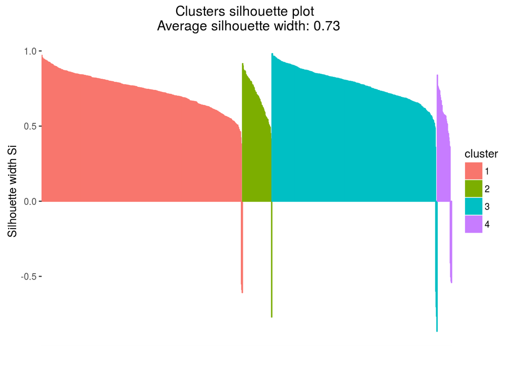

```r
fviz_silhouette(silhouette(clst_pam_r$clustering, distances_station_manual_clustering_good_reduced))
```

A więc poza wglądem wizualnym, widzimy z miar silhouette, że klastry są wyraźne.

# Jakie zmienne są skorelowane z takim ładnym klastrowaniem?

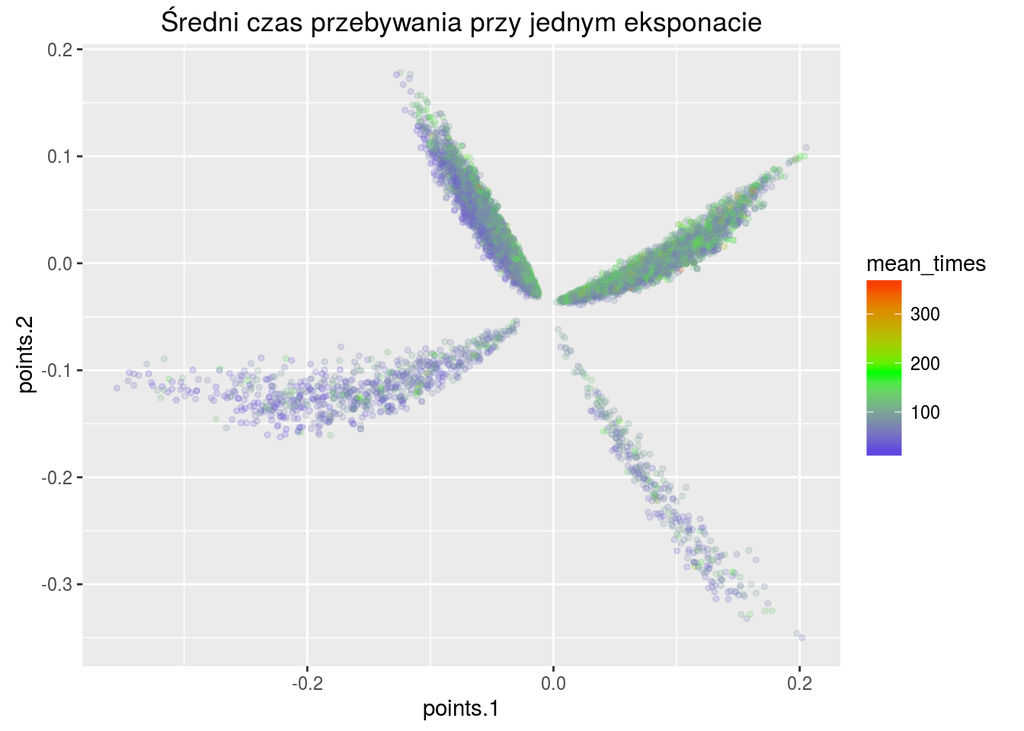

```r
ggplot(distances_station_manual_clustering_good_2d, aes(x=points.1, y=points.2, colour = mean_times)) + geom_point(size = 1, alpha=.2) +
  scale_colour_gradient2(low="blue", mid="green", high="red", midpoint = 180) + ggtitle("Średni czas przebywania przy jednym eksponacie")
```

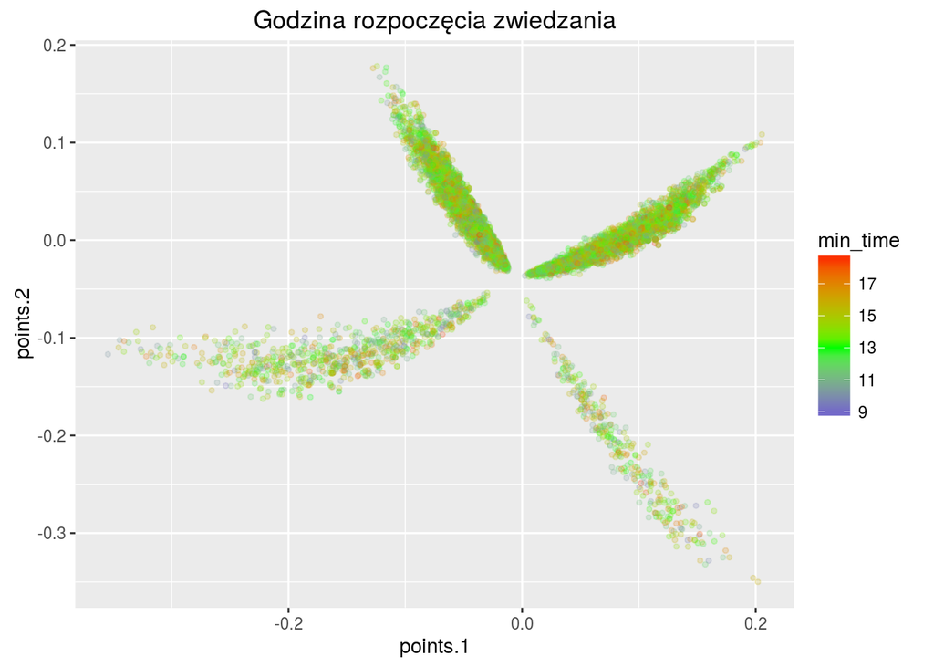

```r
ggplot(distances_station_manual_clustering_good_2d, aes(x=points.1, y=points.2, colour = min_time)) + geom_point(size = 1, alpha=.2) +
  scale_colour_gradient2(low="blue", mid="green", high="red", midpoint = 13) + ggtitle("Godzina rozpoczęcia zwiedzania")
```

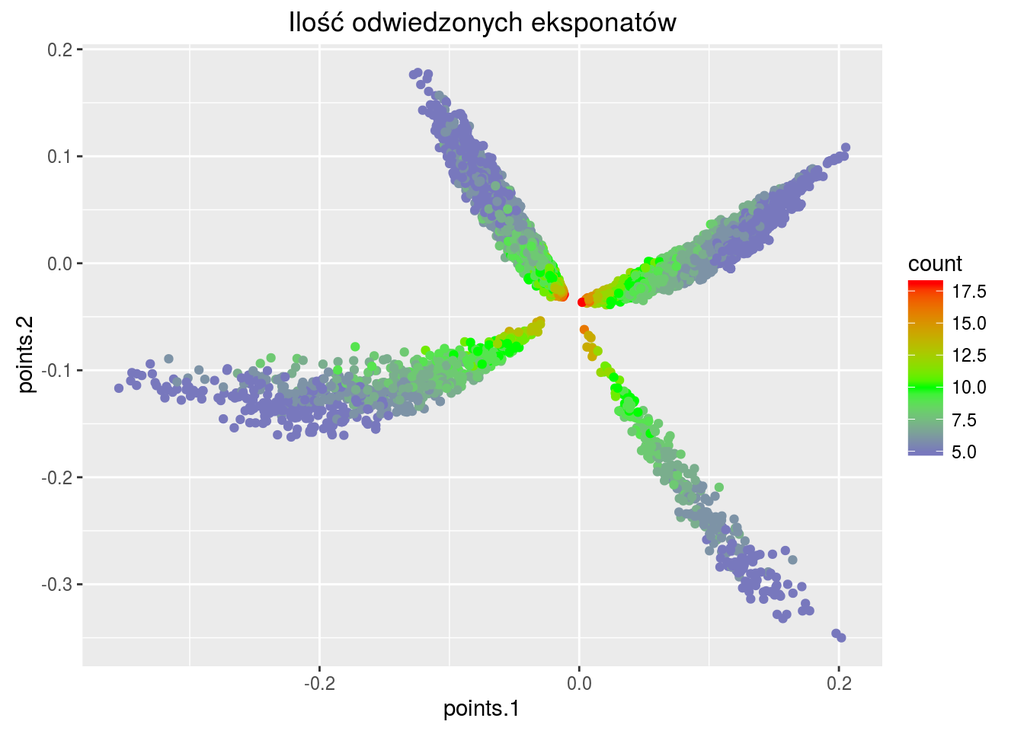

```r
ggplot(distances_station_manual_clustering_good_2d, aes(x=points.1, y=points.2, colour = count)) + geom_point() +
  scale_colour_gradient2(low="blue", mid="green", high="red", midpoint = 10) + ggtitle("Ilość odwiedzonych eksponatów")
```

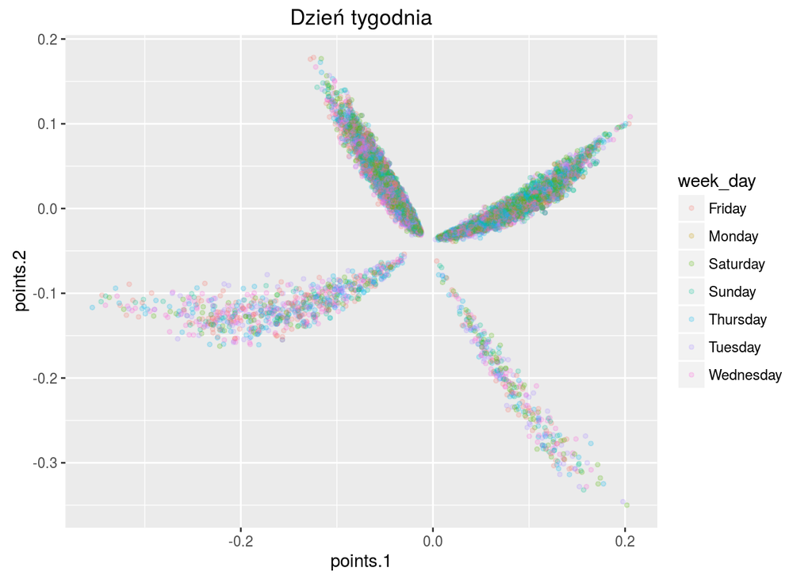

```r
ggplot(distances_station_manual_clustering_good_2d, aes(x=points.1, y=points.2, colour = week_day)) + geom_point(size = 1, alpha=.2) + ggtitle("Dzień tygodnia")
```

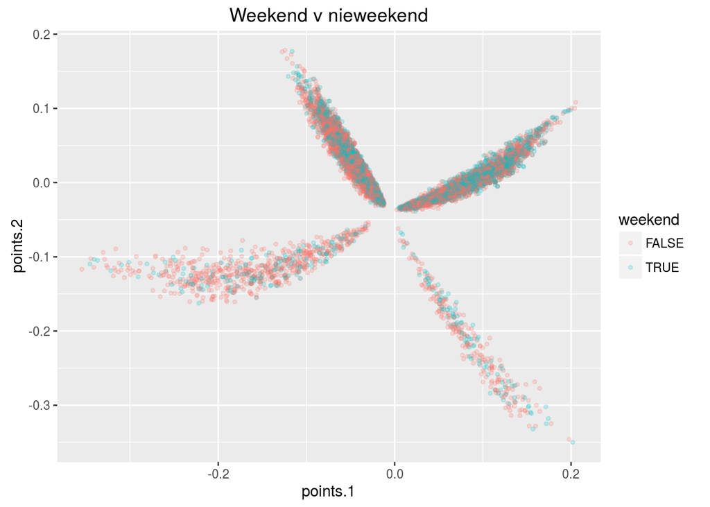

```r
ggplot(distances_station_manual_clustering_good_2d, aes(x=points.1, y=points.2, colour = weekend)) + geom_point(size = 1, alpha=.2) + ggtitle("Weekend v nieweekend")
```

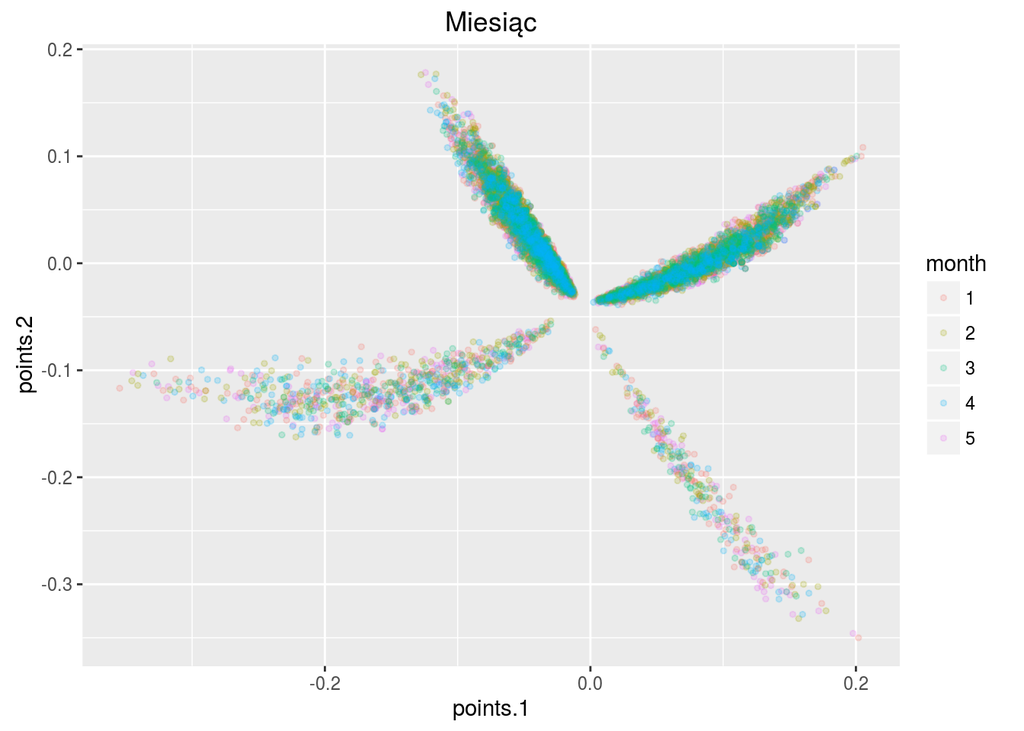

```r
ggplot(distances_station_manual_clustering_good_2d, aes(x=points.1, y=points.2, colour = month)) + geom_point(size = 1, alpha=.2) + ggtitle("Miesiąc")
```

# Podsumowanie